# Bellabeat: Understanding the Present, Unlocking the Future

Anis Ahmed

## Background

Since it was founded in 2013, Bellabeat has grown rapidly and quickly positioned itself as a tech-driven wellness company for women. This report seeks to understand the current usage of smart personal wearables using advanced analytical tools. The analytics team then aims to present findings and narrow-down proposals relevant to Bellabeat, which will allow the stakeholders to make informed and growth-oriented decisions.

## The Business Problem

Bellabeat has been able to create a strong bond with its user base. So much so that despite strong competition from far popular smart-wearable manufacturers such as Fitbit, Apple and others, Bellabeat has been able to not only maintain but grow its user base.

To understand its market position, Bellabeat aims to undergo a two-prong study: Understand usage of **Bellabeat** devices & Understand usage of **non-Bellabeat** devices. The study presented in **this report** will aim at understanding usage of **non-Bellabeat** smart devices.

Primary questions to ask in this study are:

1. What are some trends in smart device usage?
2. How could these trends apply to Bellabeat customers?
3. How could these trends help influence Bellabeat marketing strategy?

## The Stakeholders

The Stakeholders for this study are:

- Urška Sršen: Bellabeat’s cofounder and Chief Creative Office
- Sando Mur: Mathematician and Bellabeat’s cofounder; key member of the Bellabeat executive team
- Bellabeat marketing analytics team: A team of data analysts responsible for collecting, analyzing, and reporting data that helps guide Bellabeat’s marketing strategy.

## The Data - Preparing and Processing for Analysis

After downloading the data, it has been kept on the local drive for easy access. *(Currently, a shared drive isn’t available. Once a shared drive is available, the data will be stored there with access to the relevant team members.)*

Furthermore, datasets have been divided between daily, hourly and minute-level observations.

#### Installing the Relevant Packages

```r
library(tidyverse)
library(readr)
library(dplyr)
library(lubridate)
```

#### Loading the Daily-Observation Dataset

```r
daily_activity <- read.csv("~/Desktop/Data Analytics Capstone/Data/Fitabase Data 4.12.16-5.12.16/dailyActivity_merged.csv")

daily_calories <- read.csv("~/Desktop/Data Analytics Capstone/Data/Fitabase Data 4.12.16-5.12.16/dailyCalories_merged.csv")

daily_intensities <- read.csv("~/Desktop/Data Analytics Capstone/Data/Fitabase Data 4.12.16-5.12.16/dailyIntensities_merged.csv")

daily_steps <- read.csv("~/Desktop/Data Analytics Capstone/Data/Fitabase Data 4.12.16-5.12.16/dailySteps_merged.csv")

sleep_day <- read.csv("~/Desktop/Data Analytics Capstone/Data/Fitabase Data 4.12.16-5.12.16/sleepDay_merged.csv")

weight_log <- read.csv("~/Desktop/Data Analytics Capstone/Data/Fitabase Data 4.12.16-5.12.16/weightLogInfo_merged.csv")
```

#### Quick Glance into the Datasets

Running head() to see the data tables at a glance.

```r
head(daily_activity, 5)
```

```
##           Id ActivityDate TotalSteps TotalDistance TrackerDistance
## 1 1503960366    4/12/2016      13162          8.50            8.50
## 2 1503960366    4/13/2016      10735          6.97            6.97
## 3 1503960366    4/14/2016      10460          6.74            6.74
## 4 1503960366    4/15/2016       9762          6.28            6.28
## 5 1503960366    4/16/2016      12669          8.16            8.16
##   LoggedActivitiesDistance VeryActiveDistance ModeratelyActiveDistance
## 1                        0               1.88                     0.55
## 2                        0               1.57                     0.69
## 3                        0               2.44                     0.40
## 4                        0               2.14                     1.26
## 5                        0               2.71                     0.41
##   LightActiveDistance SedentaryActiveDistance VeryActiveMinutes
## 1                6.06                       0                25
## 2                4.71                       0                21
## 3                3.91                       0                30
## 4                2.83                       0                29
## 5                5.04                       0                36
##   FairlyActiveMinutes LightlyActiveMinutes SedentaryMinutes Calories
## 1                  13                  328              728     1985
## 2                  19                  217              776     1797
## 3                  11                  181             1218     1776
## 4                  34                  209              726     1745
## 5                  10                  221              773     1863
```

```r
head(daily_calories, 5)
```

```
##           Id ActivityDay Calories
## 1 1503960366   4/12/2016     1985
## 2 1503960366   4/13/2016     1797
## 3 1503960366   4/14/2016     1776
## 4 1503960366   4/15/2016     1745
## 5 1503960366   4/16/2016     1863
```

```r
head(daily_intensities, 5)
```

```
##           Id ActivityDay SedentaryMinutes LightlyActiveMinutes
## 1 1503960366   4/12/2016              728                  328
## 2 1503960366   4/13/2016              776                  217
## 3 1503960366   4/14/2016             1218                  181
## 4 1503960366   4/15/2016              726                  209
## 5 1503960366   4/16/2016              773                  221
##   FairlyActiveMinutes VeryActiveMinutes SedentaryActiveDistance
## 1                  13                25                       0
## 2                  19                21                       0
## 3                  11                30                       0
## 4                  34                29                       0
## 5                  10                36                       0
##   LightActiveDistance ModeratelyActiveDistance VeryActiveDistance
## 1                6.06                     0.55               1.88
## 2                4.71                     0.69               1.57
## 3                3.91                     0.40               2.44
## 4                2.83                     1.26               2.14
## 5                5.04                     0.41               2.71
```

```r
head(daily_steps, 5)
```

```
##           Id ActivityDay StepTotal
## 1 1503960366   4/12/2016     13162
## 2 1503960366   4/13/2016     10735
## 3 1503960366   4/14/2016     10460
## 4 1503960366   4/15/2016      9762
## 5 1503960366   4/16/2016     12669
```

```r
head(sleep_day, 5)
```

```
##           Id              SleepDay TotalSleepRecords TotalMinutesAsleep
## 1 1503960366 4/12/2016 12:00:00 AM                 1                327
## 2 1503960366 4/13/2016 12:00:00 AM                 2                384
## 3 1503960366 4/15/2016 12:00:00 AM                 1                412
## 4 1503960366 4/16/2016 12:00:00 AM                 2                340
## 5 1503960366 4/17/2016 12:00:00 AM                 1                700
##   TotalTimeInBed
## 1            346
## 2            407
## 3            442
## 4            367
## 5            712
```

```r
head(weight_log, 5)
```

```
##           Id                  Date WeightKg WeightPounds Fat   BMI
## 1 1503960366  5/2/2016 11:59:59 PM     52.6     115.9631  22 22.65
## 2 1503960366  5/3/2016 11:59:59 PM     52.6     115.9631  NA 22.65
## 3 1927972279  4/13/2016 1:08:52 AM    133.5     294.3171  NA 47.54
## 4 2873212765 4/21/2016 11:59:59 PM     56.7     125.0021  NA 21.45
## 5 2873212765 5/12/2016 11:59:59 PM     57.3     126.3249  NA 21.69
##   IsManualReport        LogId
## 1           True 1.462234e+12
## 2           True 1.462320e+12
## 3          False 1.460510e+12
## 4           True 1.461283e+12
## 5           True 1.463098e+12
```

ID and AcitivtyDate are common to all data frames. The daily_activity data frame is merged with daily_calories, daily_intensities and daily_steps with ID and AcitivtyDate as the common factors. Therefore, the daily activity dataframe will be used to analyse the daily observations.

Running n_distinct() to make sure ID count is consistent amongst all data sets.

```r
n_distinct(daily_activity$Id)
```

```
## [1] 33
```

```r
n_distinct(daily_calories$Id)
```

```
## [1] 33
```

```r
n_distinct(daily_intensities$Id)
```

```
## [1] 33
```

```r
n_distinct(daily_steps$Id)
```

```
## [1] 33
```

```r
n_distinct(sleep_day$Id)
```

```
## [1] 24
```

```r
n_distinct(weight_log$Id)
```

```
## [1] 8
```

It appears only 24 users provided sleep data and 8 users provided weight data. With just 8 users, weight data does not represent a comprehensive data set.

#### Some Cleaning of the Datasets

A quick view of the data using the str() function on the console shows that the column ‘ActivityDate’ is in the incorrect format. It is currently formatted as *character* whereas it should be formatted as *date*.

```r
str(daily_activity)
```

```
## 'data.frame':    940 obs. of  15 variables:
##  $ Id                      : num  1.5e+09 1.5e+09 1.5e+09 1.5e+09 1.5e+09 ...
##  $ ActivityDate            : chr  "4/12/2016" "4/13/2016" "4/14/2016" "4/15/2016" ...
##  $ TotalSteps              : int  13162 10735 10460 9762 12669 9705 13019 15506 10544 9819 ...
##  $ TotalDistance           : num  8.5 6.97 6.74 6.28 8.16 ...
##  $ TrackerDistance         : num  8.5 6.97 6.74 6.28 8.16 ...
##  $ LoggedActivitiesDistance: num  0 0 0 0 0 0 0 0 0 0 ...
##  $ VeryActiveDistance      : num  1.88 1.57 2.44 2.14 2.71 ...
##  $ ModeratelyActiveDistance: num  0.55 0.69 0.4 1.26 0.41 ...
##  $ LightActiveDistance     : num  6.06 4.71 3.91 2.83 5.04 ...
##  $ SedentaryActiveDistance : num  0 0 0 0 0 0 0 0 0 0 ...
##  $ VeryActiveMinutes       : int  25 21 30 29 36 38 42 50 28 19 ...
##  $ FairlyActiveMinutes     : int  13 19 11 34 10 20 16 31 12 8 ...
##  $ LightlyActiveMinutes    : int  328 217 181 209 221 164 233 264 205 211 ...
##  $ SedentaryMinutes        : int  728 776 1218 726 773 539 1149 775 818 838 ...
##  $ Calories                : int  1985 1797 1776 1745 1863 1728 1921 2035 1786 1775 ...
```

After applying the correct code, the str() function shows that ActivityDate column format has been amended.

```r
daily_activity$ActivityDate <- as.Date(daily_activity$ActivityDate, format = "%m/%d/%Y")

str(daily_activity)
```

```
## 'data.frame':    940 obs. of  15 variables:
##  $ Id                      : num  1.5e+09 1.5e+09 1.5e+09 1.5e+09 1.5e+09 ...
##  $ ActivityDate            : Date, format: "2016-04-12" "2016-04-13" ...
##  $ TotalSteps              : int  13162 10735 10460 9762 12669 9705 13019 15506 10544 9819 ...
##  $ TotalDistance           : num  8.5 6.97 6.74 6.28 8.16 ...
##  $ TrackerDistance         : num  8.5 6.97 6.74 6.28 8.16 ...
##  $ LoggedActivitiesDistance: num  0 0 0 0 0 0 0 0 0 0 ...
##  $ VeryActiveDistance      : num  1.88 1.57 2.44 2.14 2.71 ...
##  $ ModeratelyActiveDistance: num  0.55 0.69 0.4 1.26 0.41 ...
##  $ LightActiveDistance     : num  6.06 4.71 3.91 2.83 5.04 ...
##  $ SedentaryActiveDistance : num  0 0 0 0 0 0 0 0 0 0 ...
##  $ VeryActiveMinutes       : int  25 21 30 29 36 38 42 50 28 19 ...
##  $ FairlyActiveMinutes     : int  13 19 11 34 10 20 16 31 12 8 ...
##  $ LightlyActiveMinutes    : int  328 217 181 209 221 164 233 264 205 211 ...
##  $ SedentaryMinutes        : int  728 776 1218 726 773 539 1149 775 818 838 ...
##  $ Calories                : int  1985 1797 1776 1745 1863 1728 1921 2035 1786 1775 ...
```

The code has formatted the ActivityDate into *date* from *character*.

#### Merging sleep_day dataset with the daily_activity dataset using Id and ActivityDate to create a new dataset: daily_acitivty_with_sleep

This merger of datasets will create a new dataset which will include daily sleep data as an additional column to daily acitivies. This will allow us to study daily sleep patterns compared with other daily activities such as steps and calories.

To merge sleep_day dataset with the daily_activity dataset, I will first create a new ActivityDate column in the sleep_day dataset. This is in order to standardize the 2 datasets, daily_activity and sleep_day, using Id and ActivityDate.

The dataset with the new column will be called sleep_day_new:

```r
sleep_day_new <- mutate(sleep_day, ActivityDate = as.Date(SleepDay, format = "%m/%d/%Y"))
head(sleep_day_new)
```

```
##           Id              SleepDay TotalSleepRecords TotalMinutesAsleep
## 1 1503960366 4/12/2016 12:00:00 AM                 1                327
## 2 1503960366 4/13/2016 12:00:00 AM                 2                384
## 3 1503960366 4/15/2016 12:00:00 AM                 1                412
## 4 1503960366 4/16/2016 12:00:00 AM                 2                340
## 5 1503960366 4/17/2016 12:00:00 AM                 1                700
## 6 1503960366 4/19/2016 12:00:00 AM                 1                304
##   TotalTimeInBed ActivityDate
## 1            346   2016-04-12
## 2            407   2016-04-13
## 3            442   2016-04-15
## 4            367   2016-04-16
## 5            712   2016-04-17
## 6            320   2016-04-19
```

We will also include a new column with weekday names for our analysis. This will allow us to compare variables such as step or calories on particular days of the week.

```r
daily_activity_new <- mutate(daily_activity, Day = weekdays(ActivityDate))
head(daily_activity_new)
```

```
##           Id ActivityDate TotalSteps TotalDistance TrackerDistance
## 1 1503960366   2016-04-12      13162          8.50            8.50
## 2 1503960366   2016-04-13      10735          6.97            6.97
## 3 1503960366   2016-04-14      10460          6.74            6.74
## 4 1503960366   2016-04-15       9762          6.28            6.28
## 5 1503960366   2016-04-16      12669          8.16            8.16
## 6 1503960366   2016-04-17       9705          6.48            6.48
##   LoggedActivitiesDistance VeryActiveDistance ModeratelyActiveDistance
## 1                        0               1.88                     0.55
## 2                        0               1.57                     0.69
## 3                        0               2.44                     0.40
## 4                        0               2.14                     1.26
## 5                        0               2.71                     0.41
## 6                        0               3.19                     0.78
##   LightActiveDistance SedentaryActiveDistance VeryActiveMinutes
## 1                6.06                       0                25
## 2                4.71                       0                21
## 3                3.91                       0                30
## 4                2.83                       0                29
## 5                5.04                       0                36
## 6                2.51                       0                38
##   FairlyActiveMinutes LightlyActiveMinutes SedentaryMinutes Calories       Day
## 1                  13                  328              728     1985   Tuesday
## 2                  19                  217              776     1797 Wednesday
## 3                  11                  181             1218     1776  Thursday
## 4                  34                  209              726     1745    Friday
## 5                  10                  221              773     1863  Saturday
## 6                  20                  164              539     1728    Sunday
```

Now, to merge the 2 datasets and create a new dataset for sleep analysis:

```r
daily_activity_with_sleep <- merge(daily_activity_new, sleep_day_new, by = c("Id", "ActivityDate"))
head(daily_activity_with_sleep)
```

```
##           Id ActivityDate TotalSteps TotalDistance TrackerDistance
## 1 1503960366   2016-04-12      13162          8.50            8.50
## 2 1503960366   2016-04-13      10735          6.97            6.97
## 3 1503960366   2016-04-15       9762          6.28            6.28
## 4 1503960366   2016-04-16      12669          8.16            8.16
## 5 1503960366   2016-04-17       9705          6.48            6.48
## 6 1503960366   2016-04-19      15506          9.88            9.88
##   LoggedActivitiesDistance VeryActiveDistance ModeratelyActiveDistance
## 1                        0               1.88                     0.55
## 2                        0               1.57                     0.69
## 3                        0               2.14                     1.26
## 4                        0               2.71                     0.41
## 5                        0               3.19                     0.78
## 6                        0               3.53                     1.32
##   LightActiveDistance SedentaryActiveDistance VeryActiveMinutes
```

[output cut: 20 more lines]

#### Data Limitations: Does it ROCCC?

R - Raliable: The data is extracted from publicly available dataset, consented by eligible Fitbit users. It is reliable.

O - Original: The data is collected first hand from consenting Fitbit users. Even though the dataset is not released by Fitbit itself, the poster’s note clarifying that is collected from a distributed survey via Amazon Mechanical Turk has led me to accept that it is original.

C - Cited: The original poster has presented the relevant citations to the data. It is cited.

Even though the data is not current and comprehensive. However, given that it is reliable, original and cited, for the purpose of this study it ROCCCs!

#### Checking for Duplicates

```r
n_distinct(daily_activity_new$Id)
```

```
## [1] 33
```

```r
n_distinct(daily_activity_with_sleep$Id)
```

```
## [1] 24
```

A quick glance into the 2 datasets shows that daily_activity_with_sleep has less participants. This is because less participants provided their sleep data. Moreover, once the datasets were merged, rows with no sleep data were automatically omitted.

Now we will check both datasets for duplicates:

```r
sum(duplicated(daily_activity_new))
```

```
## [1] 0
```

```r
sum(duplicated(daily_activity_with_sleep))
```

```
## [1] 3
```

To remove duplicates we will run the following:

```r
daily_activity_new_ <- daily_activity_new %>%
  distinct() %>%
  drop_na()

daily_activity_with_sleep <- daily_activity_with_sleep %>%
  distinct() %>%
  drop_na
```

Now, to check if duplicates still remain:

```r
sum(duplicated(daily_activity_new))
```

```
## [1] 0
```

```r
sum(duplicated(daily_activity_with_sleep))
```

```
## [1] 0
```

The duplicates have been cleared and there doesn’t appear to be any more duplicates in the datasets. We can now go ahead and start the analysis process.

## Analysing the Data - Finding Insights and Making Inferences

#### Statistical Look into the Data

Let’s start off by calculating some statistics. We will first create statistics on steps, distance, calories and sleep for the sample population. The stats will include mean, standard deviation and median values.

```r
stats_steps <- daily_activity_with_sleep %>%
  summarise (mean_steps = mean(TotalSteps), sd_steps = sd(TotalSteps), median_steps = median(TotalSteps))
head(stats_steps)
```

```
##   mean_steps sd_steps median_steps
## 1    8514.91 4157.376         8913
```

```r
stats_distance <- daily_activity_with_sleep %>%
  summarise (mean_distance = mean(TotalDistance), sd_distance = sd(TotalDistance), median_distance = median(TotalDistance))
head(stats_distance)
```

```
##   mean_distance sd_distance median_distance
## 1       6.01239    3.043946            6.27
```

```r
stats_calories <- daily_activity_with_sleep %>%
  summarise (mean_calories = mean(Calories), sd_calories = sd(Calories), median_calories = median(Calories))
head(stats_calories)
```

```
##   mean_calories sd_calories median_calories
## 1      2389.295     758.435            2207
```

```r
stats_sleep <- daily_activity_with_sleep %>%
  summarise (mean_sleep = mean(TotalMinutesAsleep), sd_sleep = sd(TotalMinutesAsleep), median_sleep = median(TotalMinutesAsleep))
head(stats_sleep)
```

```
##   mean_sleep sd_sleep median_sleep
## 1   419.1732 118.6359        432.5
```

```r
stats_time_in_bed <- daily_activity_with_sleep %>%
  summarise (mean_time_in_bed = mean(TotalTimeInBed), sd_time_in_bed = sd(TotalTimeInBed), median_time_in_bed = median(TotalTimeInBed))
head(stats_time_in_bed)
```

```
##   mean_time_in_bed sd_time_in_bed median_time_in_bed
## 1         458.4829       127.4551                463
```

Glancing into these statistics reveals useful information on where users stand compared to the population. For instance, on average users sleep around 419 minutes daily with a standard deviation of 118 minutes. This sd is nearly 28% of the mean value which is pretty high. This indicates that the mean is spread out in the population and that there are high number of people with at least 28% better sleep time than average.

We can make similar inferences about other variables such as calories, distance and steps.

We can use this statistical information in 2 ways: (a) understanding user behavior to improve our products and services and (b) to provide this info back to the users in terms of actionable milestones via the product user interface. Providing the info back to the users will improve user interactivity with Bellabeat’s products and services. Coming back to our sleep example, if a user knows that a better sleep time would be *mean + 1/2 sd* for instance they would tend to make an effort to achieve this sleep time, either by sleeping early or waking up late.

#### Understading Users’ Weekly Routine

Let’s start off by creating a new dataset to group steps against each day.

```r
#First, we will order the dataset by the specified vector. This is because in default R arranges by alphabet
daily_activity_with_sleep$Day <- ordered(daily_activity_with_sleep$Day, levels = c("Monday", "Tuesday", "Wednesday", "Thursday", "Friday", "Saturday", "Sunday"))

#Then we create the new dataset
day_steps_distance_sleep_calories <- daily_activity_with_sleep %>%
  group_by(Day) %>%
  summarise(avg_steps = mean(TotalSteps), avg_distance = mean(TotalDistance), avg_calories = mean(Calories), avg_sleep = mean(TotalMinutesAsleep))
head(day_steps_distance_sleep_calories, 7)
```

```
## # A tibble: 7 × 5
##   Day       avg_steps avg_distance avg_calories avg_sleep
##   <ord>         <dbl>        <dbl>        <dbl>     <dbl>
## 1 Monday        9273.         6.54        2432.      420.
## 2 Tuesday       9183.         6.43        2496.      405.
## 3 Wednesday     8023.         5.72        2378.      435.
## 4 Thursday      8184.         5.77        2307.      401.
## 5 Friday        7901.         5.51        2330.      405.
## 6 Saturday      9871.         7.02        2507.      419.
## 7 Sunday        7298.         5.18        2277.      453.
```

Now, We will use this dataset to graph out users’ daily routine.

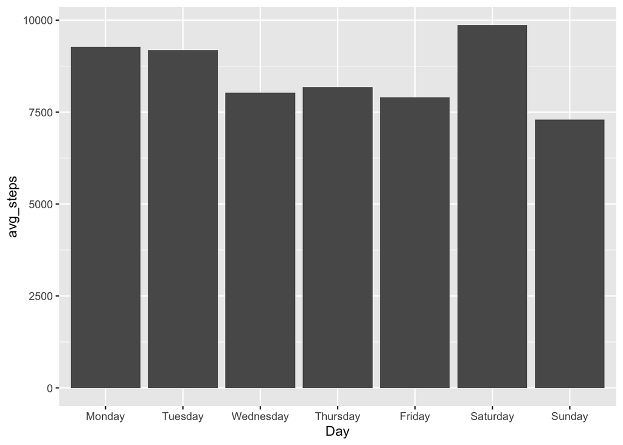

```r
ggplot(data = day_steps_distance_sleep_calories)+
  geom_col(mapping = aes(Day, avg_steps))
```

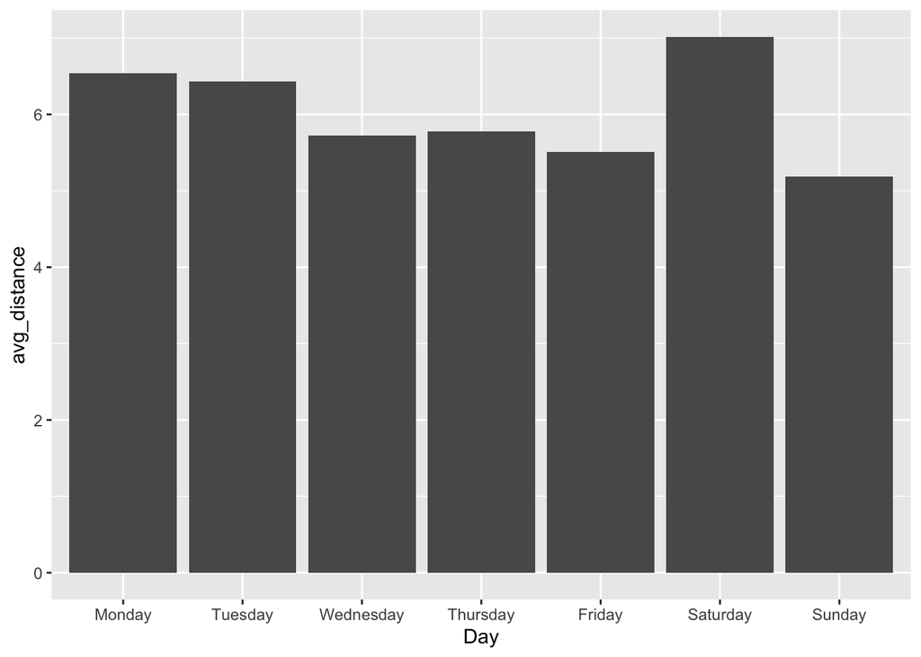

```r
ggplot(data = day_steps_distance_sleep_calories)+
  geom_col(mapping = aes(Day, avg_distance))
```

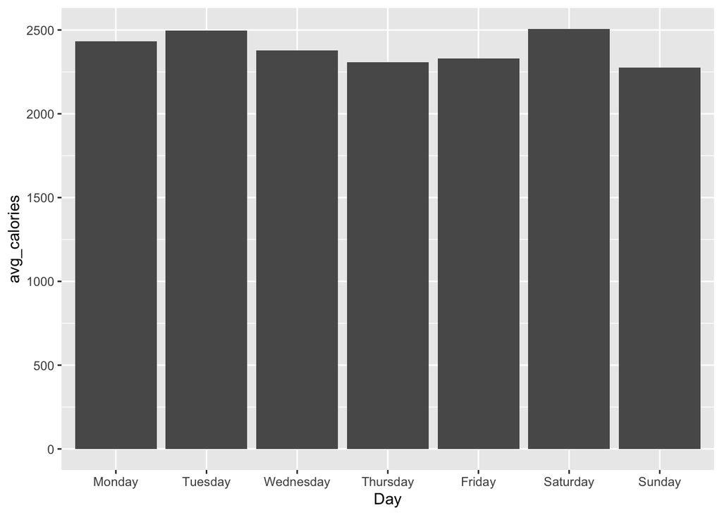

```r
ggplot(data = day_steps_distance_sleep_calories)+
  geom_col(mapping = aes(Day, avg_calories))
```

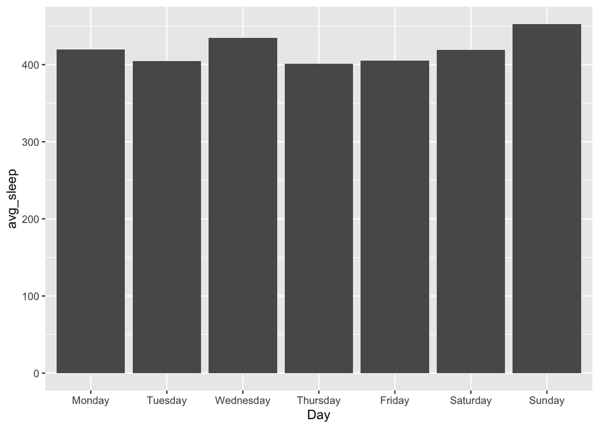

```r
ggplot(data = day_steps_distance_sleep_calories)+
  geom_col(mapping = aes(Day, avg_sleep))
```

From these plots, we can notice that as the week progresses, users’ step count decreases with the exception of Saturday. We can infer that since Saturday is the first day of the weekend, people tend to make the best use of it and end up taking more steps.

Also, without surprise, we notice that Steps and Distance charts are identical to each other.

#### Understanding Correlation Between Steps, Distance, Calories and Sleep

##### Steps vs Distance

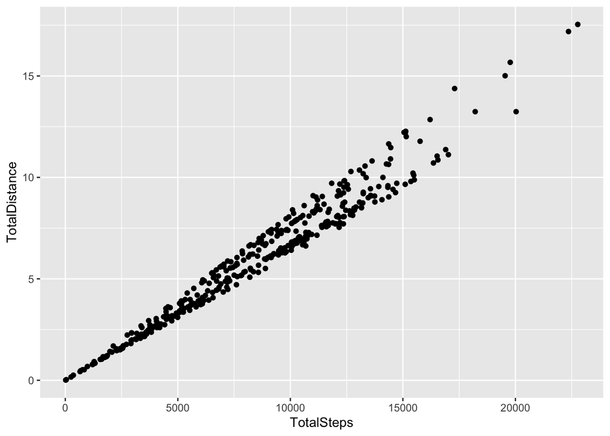

```r
ggplot(data = daily_activity_with_sleep)+
  geom_point(mapping = aes(x = TotalSteps, y = TotalDistance))
```

This plot confirms our suspicion that steps and distance correlate to each. In addition, this plot reveals one other useful info. The plot tends to expand with steps. This suggests that some users cover more distance with same number of steps. This could be due to various factors such as:

- Users’ height and
- Users’ step length.

##### Steps vs Calories

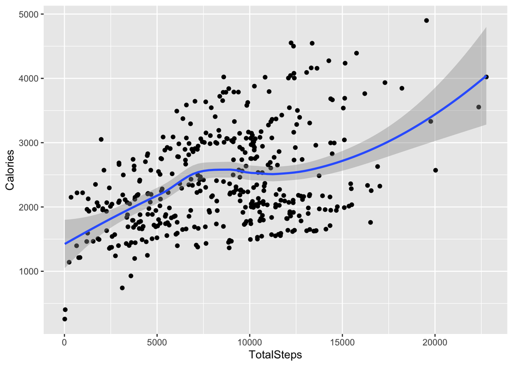

```r
ggplot(data = daily_activity_with_sleep)+
  geom_point(mapping = aes(x = TotalSteps, y = Calories))+
  geom_smooth(mapping = aes(x = TotalSteps, y = Calories))
```

This plot shows that steps and calories are slightly positively correlated. We can make an assumption that as step count rises, more calories are burned.

##### Steps vs Sleep

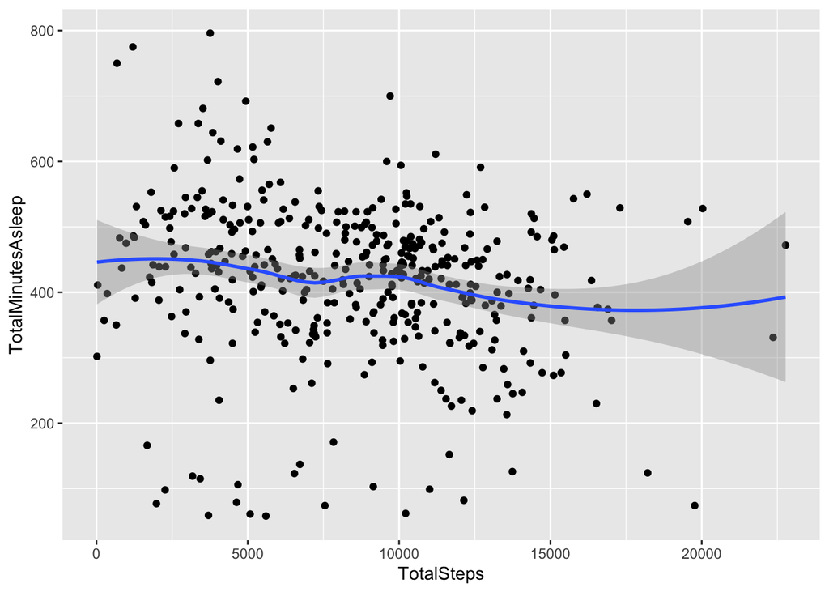

```r
ggplot(data = daily_activity_with_sleep)+
  geom_point(mapping = aes(x = TotalSteps, y = TotalMinutesAsleep))+
  geom_smooth(mapping = aes(x = TotalSteps, y = TotalMinutesAsleep))
```

This plot shows an indifferent relationship between steps and sleep. Conventional wisdom would dictate that with a large step count users would get more sleep. This is because a large step count would indicate that a user generally had an active day. However, the plot does not confirm this hypothesis. This could be due to multiple factors:

- Perhaps users tend to follow a set routine rather than sleep when they are tired.
- Pteps may not be an accurate measure of tiredness.
  - Perhaps users are going to the gym and exercising weights. Here, users do not take much steps but do other body movements leading to tiredness.
  - Perhaps users are mental fatigued at work